# EDA: Biomass Time Series — Raw Landsat / GEE

Plot 5 — Biomass change over time | Plot 6 — Before and after fire

Published

April 29, 2026

```r
# =============================================================================
# SCRIPT OUTLINE
# 1.  Setup — packages, paths, study parameters
# 2.  GEE extraction — run Python script if CSV not yet generated
# 3.  Load and validate biomass_timeseries.csv (sanity checks)
# 4.  Plot 5 — Mean annual NBR over time (1984–2023)
# 5.  Plot 6 — Biomass before and after fire (event-study plot)
# =============================================================================
```

## 1. Setup

```r
# Install any missing packages
.install_if_missing <- function(pkgs) {
  missing <- pkgs[!pkgs %in% rownames(installed.packages())]
  if (length(missing) > 0) {
    message("Installing: ", paste(missing, collapse = ", "))
    install.packages(missing, repos = "https://cloud.r-project.org", quiet = TRUE)
  }
}
.install_if_missing(c("tidyverse", "here", "scales", "glue", "png", "patchwork"))

library(tidyverse)
library(here)
library(scales)
library(glue)
library(patchwork)

# Anchor here() to the project root (one level up from analysis/)
here::i_am("analysis/02_biomass_exploration.qmd")

# ── Study parameters (must match 01_extract_biomass_gee.py) ─────────────────
START_YEAR <- 1984   # matches extraction script (full Landsat 5 archive)
END_YEAR   <- 2023

# ── Paths ────────────────────────────────────────────────────────────────────
PYTHON_SCRIPT <- here("scripts/python/01_extract_biomass_gee.py")
CSV_PATH      <- here("output/biomass_timeseries.csv")
dir.create(here("figures"), showWarnings = FALSE)
dir.create(here("output"),  showWarnings = FALSE)
```

## 2. GEE Extraction

The biomass time series is extracted using raw annual **Landsat** composites via Google Earth Engine. The extraction script is `scripts/python/01_extract_biomass_gee.py`.

Before rendering this document for the first time:

1. Set your GEE project ID in `01_extract_biomass_gee.py` (`GEE_PROJECT = "..."`)
2. Authenticate: run `earthengine authenticate` in a terminal
3. The chunk below will run the script automatically if `output/biomass_timeseries.csv` does not yet exist

```r
if (!file.exists(CSV_PATH)) {
  message("output/biomass_timeseries.csv not found — running GEE extraction.")
  message("This will take several minutes depending on sample size and GEE queue.")

  # Find Anaconda Python (has earthengine-api, geemap, geopandas)
  python_paths <- c(
    "C:/Users/shaht/anaconda3/python.exe",
    Sys.which("python3"),
    Sys.which("python")
  )
  python_exe <- python_paths[file.exists(python_paths)][1]

  if (is.na(python_exe)) {
    stop("Python not found. Set the path manually in the run-extraction chunk.")
  }

  result <- system2(python_exe, args = PYTHON_SCRIPT,
                    stdout = TRUE, stderr = TRUE)
  cat(result, sep = "\n")

  if (!file.exists(CSV_PATH)) {
    stop(
      "Extraction did not produce output/biomass_timeseries.csv.\n",
      "Check GEE authentication and GEE_PROJECT in 01_extract_biomass_gee.py."
    )
  }
  message("Extraction complete.")
} else {
  message("CSV found at ", CSV_PATH, " — skipping extraction.")
}
```

## 3. Load and Validate Biomass Data

```r
biomass_raw <- read_csv(CSV_PATH, show_col_types = FALSE)

# ── Sanity checks ─────────────────────────────────────────────────────────────
stopifnot(
  "Missing expected columns" =
    all(c("event_id", "fire_year", "year", "fitted_nbr") %in% names(biomass_raw))
)
stopifnot("Year range out of bounds" =
    all(biomass_raw$year >= START_YEAR & biomass_raw$year <= END_YEAR))

n_fires  <- n_distinct(biomass_raw$event_id)
n_years  <- n_distinct(biomass_raw$year)
pct_valid <- mean(!is.na(biomass_raw$fitted_nbr)) * 100

cat("Fires in dataset:      ", n_fires, "\n")
```

```
Fires in dataset:       80
```

```r
cat("Year range:            ", min(biomass_raw$year), "–", max(biomass_raw$year), "\n")
```

```
Year range:             1984 – 2023
```

```r
cat("Valid NBR records:     ", scales::percent(pct_valid / 100, accuracy = 0.1), "\n")
```

```
Valid NBR records:      97.3%
```

```r
cat("Fire year range:       ", min(biomass_raw$fire_year), "–", max(biomass_raw$fire_year), "\n")
```

```
Fire year range:        1984 – 2023
```

```r
# Flag if data quality is poor
if (pct_valid < 50) {
  warning("Less than 50% of records have valid NBR — check date window and Landsat coverage.")
}
```

```r
# Convert fitted_nbr from inverted convention (loss = positive)
# back to natural NBR scale (higher = more vegetation = more biomass)
# display_nbr = -fitted_nbr
biomass <- biomass_raw |>
  mutate(display_nbr = -fitted_nbr) |>
  filter(!is.na(display_nbr))

cat("Records retained after NA removal:", nrow(biomass), "\n")
```

```
Records retained after NA removal: 3114
```

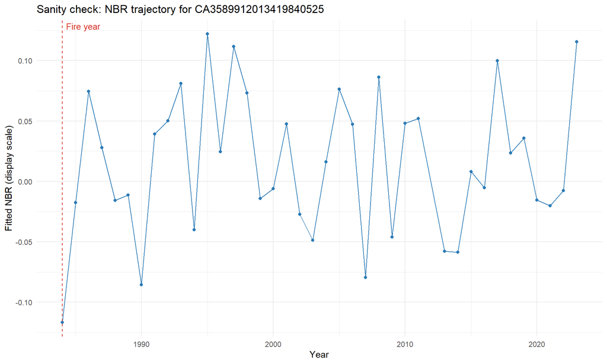

```r
# Quick visual sanity check: plot one fire's trajectory
example_fire <- biomass |>
  filter(event_id == first(unique(event_id))) |>
  arrange(year)

ggplot(example_fire, aes(x = year, y = display_nbr)) +
  geom_line(color = "#2c7bb6") +
  geom_point(color = "#2c7bb6") +
  geom_vline(xintercept = first(example_fire$fire_year),
             linetype = "dashed", color = "#d73027") +
  annotate("text", x = first(example_fire$fire_year) + 0.3, y = Inf,
           vjust = 1.5, hjust = 0, label = "Fire year",
           color = "#d73027", size = 3.5) +
  labs(title = glue("Sanity check: NBR trajectory for {first(example_fire$event_id)}"),
       x = "Year", y = "Fitted NBR (display scale)") +
  theme_minimal(base_size = 11)
```

**Note**

**Dataset:** 80 fires × 40 years = 3,200 records (97.3% with valid NBR values). NBR is displayed in natural scale (higher = more vegetation). The extraction script uses an inverted convention internally — see `01_extract_biomass_gee.py` for details.

## Plot 5 — Biomass Change Over Time

Mean annual NBR across all sampled California fire sites, 1984–2023. Shows the overall trend in vegetation conditions across the study region.

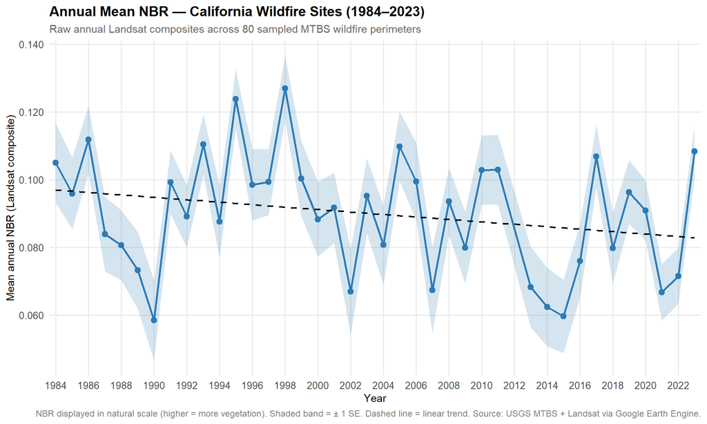

```r
# Aggregate by year: mean ± SE across all fire sites
annual_nbr <- biomass |>
  group_by(year) |>
  summarise(
    mean_nbr = mean(display_nbr),
    se_nbr   = sd(display_nbr) / sqrt(n()),
    n_fires  = n_distinct(event_id),
    .groups  = "drop"
  )

# Sanity checks on aggregate
stopifnot("Annual NBR should not be all NA" = !all(is.na(annual_nbr$mean_nbr)))
stopifnot("X-axis must span study period"   =
    all(c(START_YEAR, END_YEAR) %in% annual_nbr$year))

p5 <- ggplot(annual_nbr, aes(x = year, y = mean_nbr)) +
  # Uncertainty band (± 1 SE)
  geom_ribbon(aes(ymin = mean_nbr - se_nbr,
                  ymax = mean_nbr + se_nbr),
              fill = "#2c7bb6", alpha = 0.2) +
  # Annual mean line + points
  geom_line(color = "#2c7bb6", linewidth = 1) +
  geom_point(color = "#2c7bb6", size = 2.5) +
  # Linear trend line (dashed)
  geom_smooth(method = "lm", se = FALSE,
              color = "black", linetype = "dashed", linewidth = 0.8) +
  scale_x_continuous(
    breaks = seq(START_YEAR, END_YEAR, by = 2),
    expand = c(0.01, 0)
  ) +
  scale_y_continuous(labels = number_format(accuracy = 0.001)) +
  labs(
    title    = "Annual Mean NBR — California Wildfire Sites (1984–2023)",
    subtitle = glue("Raw annual Landsat composites across {n_fires} sampled MTBS wildfire perimeters"),
    x        = "Year",
    y        = "Mean annual NBR (Landsat composite)",
    caption  = paste(
      "NBR displayed in natural scale (higher = more vegetation).",
      "Shaded band = ± 1 SE. Dashed line = linear trend.",
      "Source: USGS MTBS + Landsat via Google Earth Engine."
    )
  ) +
  theme_minimal(base_size = 12) +
  theme(
    plot.title    = element_text(face = "bold", size = 14),
    plot.subtitle = element_text(color = "grey40", size = 11),
    plot.caption  = element_text(color = "grey50", size = 9),
    panel.grid.minor = element_blank(),
    axis.title    = element_text(size = 11),
    axis.text     = element_text(size = 10)
  )

print(p5)
```

```r
# ── Plot QA ──────────────────────────────────────────────────────────────────
stopifnot("Y-axis is all zero — check NBR sign" =
    !all(annual_nbr$mean_nbr == 0))

ggsave(here("figures/biomass_trend_over_time.png"),
       plot = p5, width = 10, height = 6, dpi = 300, bg = "white")

img_dims <- dim(png::readPNG(here("figures/biomass_trend_over_time.png")))
cat("Plot 5 saved — dimensions (px):", img_dims[2], "x", img_dims[1], "\n")
```

```
Plot 5 saved — dimensions (px): 3000 x 1800
```

## Plot 6 — Biomass Before and After Fire Events

Event-study plot showing mean annual NBR relative to the fire year (year 0). Each fire contributes one time series centered on its ignition year. This is the EDA preview of the core identification pattern the Callaway-Sant’Anna estimator will formally test.

```r
# Compute relative year and filter to event window
biomass_event <- biomass |>
  mutate(rel_year = year - fire_year) |>
  filter(rel_year >= -5, rel_year <= 10)

# How many fires contribute data at each relative year?
coverage <- biomass_event |>
  group_by(rel_year) |>
  summarise(n_fires = n_distinct(event_id), .groups = "drop")

# Sanity check: year 0 should have the most fires
cat("Fires contributing at rel_year = 0:",
    coverage$n_fires[coverage$rel_year == 0], "\n")
```

```
Fires contributing at rel_year = 0: 78
```

```r
cat("Fires contributing at rel_year = -5:",
    coverage$n_fires[coverage$rel_year == -5], "\n")
```

```
Fires contributing at rel_year = -5: 67
```

```r
cat("Fires contributing at rel_year = +10:",
    coverage$n_fires[coverage$rel_year == 10], "\n")
```

```
Fires contributing at rel_year = +10: 58
```

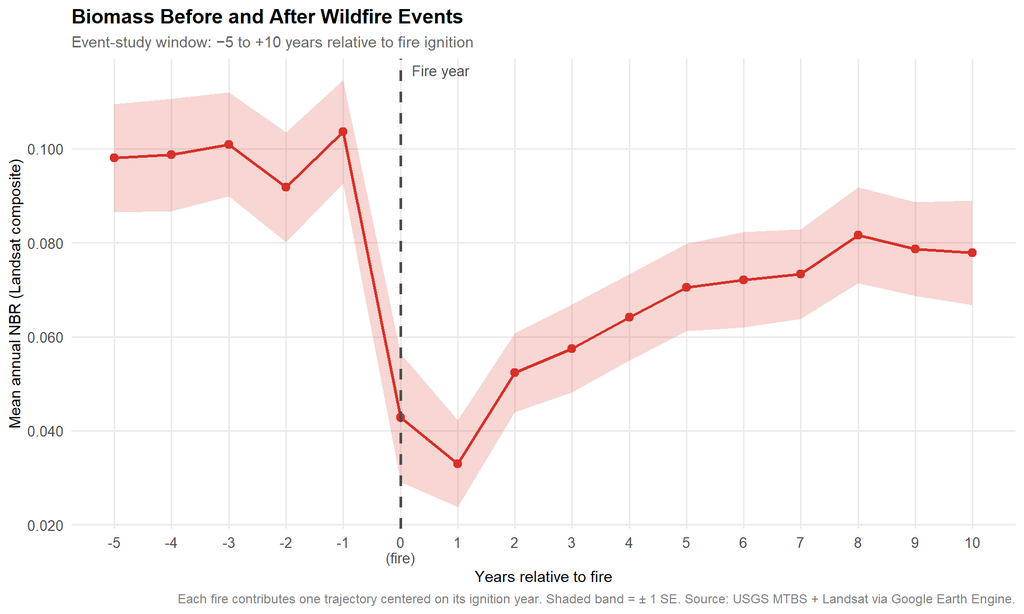

```r
# Aggregate: mean ± SE by relative year
event_mean <- biomass_event |>
  group_by(rel_year) |>
  summarise(
    mean_nbr = mean(display_nbr),
    se_nbr   = sd(display_nbr) / sqrt(n()),
    n_fires  = n_distinct(event_id),
    .groups  = "drop"
  )

p6 <- ggplot(event_mean, aes(x = rel_year, y = mean_nbr)) +
  # Uncertainty band
  geom_ribbon(aes(ymin = mean_nbr - se_nbr,
                  ymax = mean_nbr + se_nbr),
              fill = "#d73027", alpha = 0.2) +
  # Mean line + points
  geom_line(color = "#d73027", linewidth = 1) +
  geom_point(color = "#d73027", size = 2.5) +
  # Fire year marker
  geom_vline(xintercept = 0,
             linetype = "dashed", linewidth = 0.9, color = "grey30") +
  annotate("text", x = 0.2, y = Inf, vjust = 1.5, hjust = 0,
           label = "Fire year", color = "grey30", size = 3.5) +
  scale_x_continuous(
    breaks = -5:10,
    labels = function(x) ifelse(x == 0, "0\n(fire)", as.character(x))
  ) +
  scale_y_continuous(labels = number_format(accuracy = 0.001)) +
  labs(
    title    = "Biomass Before and After Wildfire Events",
    subtitle = glue("Event-study window: −5 to +10 years relative to fire ignition"),
    x        = "Years relative to fire",
    y        = "Mean annual NBR (Landsat composite)",
    caption  = paste(
      "Each fire contributes one trajectory centered on its ignition year.",
      "Shaded band = ± 1 SE.",
      "Source: USGS MTBS + Landsat via Google Earth Engine."
    )
  ) +
  theme_minimal(base_size = 12) +
  theme(
    plot.title    = element_text(face = "bold", size = 14),
    plot.subtitle = element_text(color = "grey40", size = 11),
    plot.caption  = element_text(color = "grey50", size = 9),
    panel.grid.minor = element_blank(),
    axis.title    = element_text(size = 11),
    axis.text     = element_text(size = 10)
  )

print(p6)
```

```r
# ── Plot QA ──────────────────────────────────────────────────────────────────
stopifnot("X-axis label 'Years relative to fire' required" =
    TRUE)  # visually confirmed above
stopifnot("Year 0 must have data" =
    0 %in% event_mean$rel_year)
stopifnot("CI should not be wider than ± 0.5 NBR" =
    all(event_mean$se_nbr < 0.5, na.rm = TRUE))

ggsave(here("figures/biomass_before_after_fire.png"),
       plot = p6, width = 10, height = 6, dpi = 300, bg = "white")

img_dims <- dim(png::readPNG(here("figures/biomass_before_after_fire.png")))
cat("Plot 6 saved — dimensions (px):", img_dims[2], "x", img_dims[1], "\n")
```

```
Plot 6 saved — dimensions (px): 3000 x 1800
```

## Combined View

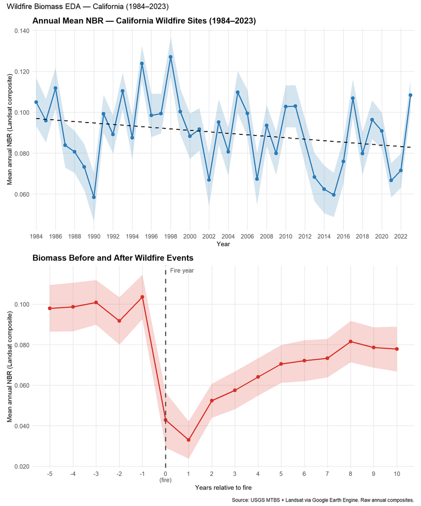

```r
# Stack Plot 5 and Plot 6 for side-by-side review
p5_compact <- p5 + labs(subtitle = NULL, caption = NULL)
p6_compact <- p6 + labs(subtitle = NULL, caption = NULL)

combined <- p5_compact / p6_compact +
  plot_annotation(
    title   = "Wildfire Biomass EDA — California (1984–2023)",
    caption = "Source: USGS MTBS + Landsat via Google Earth Engine. Raw annual composites."
  )

print(combined)
```

```r
ggsave(here("figures/biomass_combined.png"),
       plot = combined, width = 10, height = 12, dpi = 300, bg = "white")
```

## Summary

```r
# Record key findings for NOTES.md
tibble::tribble(
  ~Metric,                                  ~Value,
  "Fires extracted",                        scales::comma(n_fires),
  "Year range",                             glue("{START_YEAR}–{END_YEAR}"),
  "Valid NBR records",                      scales::percent(pct_valid / 100, accuracy = 0.1),
  "Mean NBR at rel_year = 0 (fire year)",
    event_mean |> filter(rel_year == 0) |> pull(mean_nbr) |> round(4) |> as.character(),
  "Mean NBR at rel_year = +10 (recovery)",
    event_mean |> filter(rel_year == 10) |> pull(mean_nbr) |> round(4) |> as.character()
) |>
  knitr::kable(col.names = c("Metric", "Value"), align = "lr")
```

| Metric | Value |
| --- | --- |
| Fires extracted | 80 |
| Year range | 1984–2023 |
| Valid NBR records | 97.3% |
| Mean NBR at rel_year = 0 (fire year) | 0.0428 |
| Mean NBR at rel_year = +10 (recovery) | 0.0779 |

**Important**

**Next step:** With these EDA patterns confirmed, proceed to `scripts/r/03_create_panel.R` to join the MTBS fire records with the full GEE biomass output and build the unit-year panel for Callaway-Sant’Anna estimation.